# STK4900 - Statistical Methods and Applications

Compiled Lecture Notes

Olivia Beyer Bruvik

Spring 2021

# Lecture 1

## Topics

1. Intro / Exam
2. Descriptive methods
3. Data and Probability models
4. Normal distributions
5. Estimation and confidence intervals
6. Hypothesis testing and p-values
7. Robustness and bootstrapping

https://www.uio.no/studier/emner/matnat/math/STK4900/v21/lectures/lecture1.pdf

## Exam

### Format

- Answer questions about analyses of data sets based on given outputs of R
- Exam will be similar to previous years (except 2020)
- All examination aids are allowed

### Submission

- One PDF document
- Take photos of hand writing / R markdown / Word?
- Premake word doc or R markdown with useful notes and equations
- Remove personal info https://www.uio.no/english/studies/examinations/submissions/submit-answer/submit-file-upload.html.

## Descriptive Methods

### Mean, median, SD

- mean, ${\bar{x}=\frac{1}{n}\sum_{i=1}^{n}{\bar{x}}}$
- median, med
- standard deviation, $s = \sqrt{\frac{1}{1-n}sum_{i=1}^{n}(x_i-\bar{x})^2}$

### Illustrations

- histograms
- empirical cumulative distribution (ecdf)
- boxplot

### Data, $\bar{x},...,x_n$

- replications of the same measurement or observations on random sample of population
- numerical or categorical

```r
# Descriptive methods
summary(cars$speed)
```

```
##    Min. 1st Qu.  Median    Mean 3rd Qu.    Max.
##     4.0    12.0    15.0    15.4    19.0    25.0
```

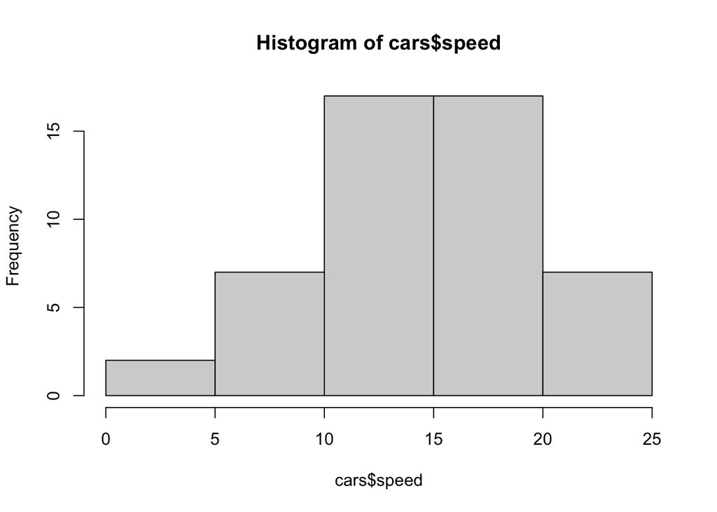

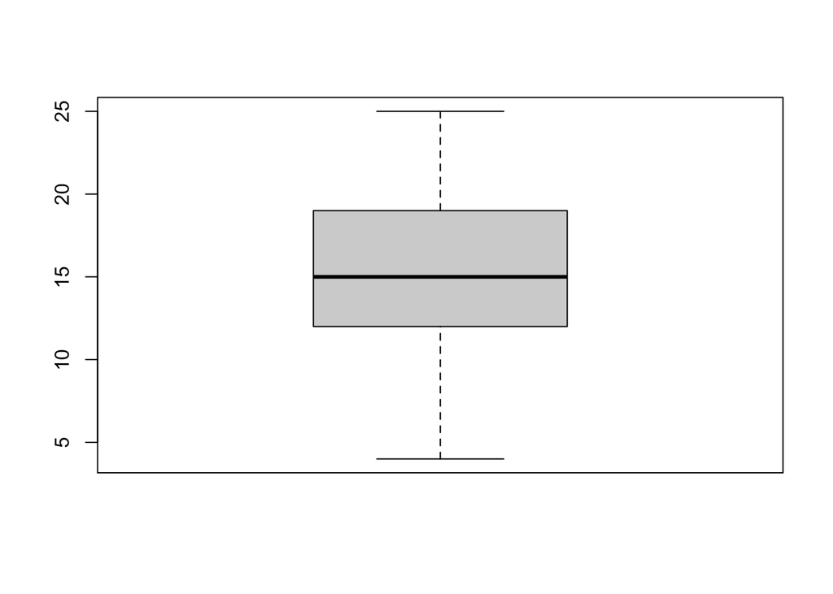

```r
# Illustrations
hist(cars$speed)
boxplot(cars$speed)
```

## Data and Probability models

### Random variable, X

- Data assumed independent replications of a random variable, X
- distribution described by:
1. probability density (histogram), $f(x)$,
2. or a cumulative distribution function (ecdf), $F(x)$

Computing probability that a realization of X falls in a certain interval:
$${P(a<X\leq{b}) = \int_{a}^{b}f(x)dx = F(b) - F(a)}$$

## Normal distributions

### Distributions of continuously distributed random variables

1. Mean or expectation: $\mu = E(X) = \int_{-\infty}^{\infty}xf(x)dx$
2. Variance: $\sigma^2=Var(X)=\int_{-\infty}^{\infty}(x-\mu)^2f(x)dx$
3. Standard variation: $\sigma=sd(X)=\sqrt{Var(X)}$

Similar formulas with sums apply for discrete random variables

### Properties of expectation and variance

$E(a+bX) = a+bE(X)$  
$E(X+Y) = E(X)+E(Y)$

$Var(a+bX)=b^2Var(X)$  
$Var(X+Y)=Var(X)+Var(Y)$, where X and Y are independent

### Law of Large Numbers

Suppose that $\bar{x},...,x_n$ are independent replications of a random variable X with mean $\mu$ and standard deviation $\sigma$, then
$$\bar{x} \to \mu \\
s \to \sigma$$
as $n$ increases.

### Normal distributions

$X \sim N(\mu,\sigma^2)$ - Random variable X is normally distributed with mean $\mu$ and SD $\sigma$.
$$f(x)=\frac{1}{\sigma\sqrt{2\pi}}*e^{-\frac{1}{2}*(\frac{x-\mu}{\sigma})^2}$$

### Standard Normal distribution

$Z \sim N(0,1)$

1. $If \space X \sim N(\mu,\sigma^2), \space then \space Z = \frac{X-\mu}{\sigma} \sim N(0,1)$
2. Suppose that $x_1,...,x_n$ are independent replications of a random variable $X \sim N(\mu,\sigma^2)$, then $\bar{x} \sim N(\mu,\sigma^2/n)$

Central Limit Theorem  
$n \to \infty$: Result two holds approximately also when $x_1,...,x_n$ is a random sample from another distribution than the normal

## Estimation and confidence intervals (14)

### Theta

$\theta$: a parameter describing the probability model (mean or SD), or function of model parameters (coefficient of variation of $\frac{\sigma}{\mu}$).

Mean $\bar{x}$ to estimate the mean $\mu$ of distribution: $\hat{\mu}=\bar{x}$

We consider unbiased estimators, ie. $E(\hat{\theta}) = \theta$

### Standard error

$$se(\hat{\theta}) = \sqrt{Var(\hat{\theta})}$$

$$\hat{\mu} = \bar{x} \to se(\bar{x}) = \frac{\sigma}{\sqrt{n}} = \frac{s}{\sqrt{n}}$$

$$\downarrow se \propto \downarrow s \propto \uparrow n$$

### Confidence Intervals

$$(\hat{\theta} - c * se(\hat{\theta}), \space \hat{\theta} + c*se(\hat{\theta})) = \hat{\theta} \pm c*se(\hat{\theta})$$
#### Confidence Coefficient of Confidence Interval The probability that the interval contains the unknown quantity:
$$P(L< \theta < U) = 1-\alpha$$

### Confidence interval for the mean µ (17)

Suppose $x_1,...,x_n$ is a random sample from $N(\mu,\sigma^2)$.

- $\mu_0$ is the mean for X
- $\hat{x}$ is the empiric mean
- $s$ is the empiric standard deviation

#### Sigma known

$\bar{x} \sim N(\mu, \frac{\sigma^2}{n})$ and a confidence interval takes the form:

$$\bar{x} \pm c * \frac{\sigma}{\sqrt{n}}$$
c is defined by:

$$P(\bar{x} - c * \frac{\sigma}{\sqrt{n}} < \mu < \bar{x} + c * \frac{\sigma}{\sqrt{n}}) = 1- \alpha$$

One may find c from a table of the standard normal distribution. In particular for a 95% CI we have c = 1.96.

#### Sigma unknown

When $\sigma$ is unknown, we estimate the empirical SD, s.

Confidence interval takes the form:

$$\bar{x} \pm c * \frac{s}{\sqrt{n}}$$
Use t-distribution with n-1 df to determine c (95% CI = 2.10).

## Hypothesis testing and p-values

$H_0: \theta \leq \theta_0$ versus the (one-sided) alternative hypothesis $H_A: \theta>\theta_0$.

### P-values

The probability, when $H_0$ is true, that the test statistic is a value equal to or more extreme than the one observed.

Testing null hypothesis, $H_0: \mu \leq \mu_0$, versus the alternative $H_A:\mu > \mu_0$

### Test for the mean µ

#### σ known

We reject $H_0$ for large values of test statistic:

$$z = \frac{\hat{x}-\mu_0}{\frac{\sigma}{\sqrt{n}}}$$
Under $H_0$, the test statistic is standard normally distributed.

Used to compute one-sided P-value:
$$P = P(Z>z), \space where \space Z \sim N(0,1)$$

#### σ unknown

We reject $H_0$ for large values of test statistic:

$$t = \frac{\hat{x}-\mu_0}{\frac{s}{\sqrt{n}}}$$
Under $H_0$, the test statistic is t-distributed w/ n-1 degrees of freedom.

Used to compute one-sided P-value:
$$P = P(T>t), \text{where T is t-distributed with n-1 df}$$

### Comparing two groups

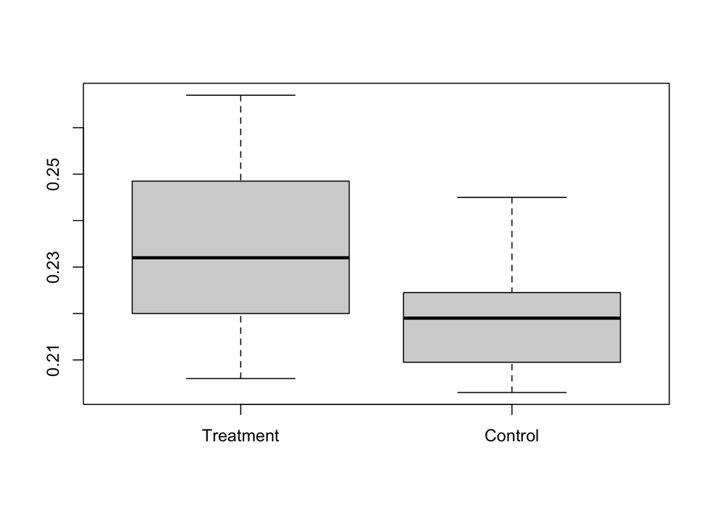

#### Assumption

Equal variances in the two groups, $\sigma_1^2 = \sigma_2^2$

$\mu_2 - \mu_1 \approx \bar{x}_2 - \bar{x}_1$

#### Confidence Intervals

95% confidence interval for $\mu_2 - \mu_1$:
$$\bar{x}_2 - \bar{x}_1 \pm c * se(\bar{x}_2 - \bar{x}_1),\space where \\
\text{c is the upper 97.5% percentile in the t-distribution with n1+n2-2 df}$$

and

$$se(\bar{x}_2 - \bar{x}_1) = s_p \sqrt{(\frac{1}{n_1} + \frac{1}{n_2})}, \space where \\
s_p = \sqrt{\frac{n_1-1}{n_1+n_2-2}s_1^2 + \frac{n_2-1}{n_1+n_2-2}s_2^2}$$

#### Test statistic

$H_0:\mu_1 = \mu_2$ versus the (two-sided) alternative $H_A:\mu_1 \neq \mu_2$

We reject for $H_0$ for large values of test statistic |t|:

$$t = \frac{\bar{x}_2 - \bar{x}_1}{se(\bar{x}_2 - \bar{x})}$$

Under H_0 the test statistic is t-distributed with $n_1+n_2-2$ df.

P-value (two-sided): $P=2P(T>|t|)$, where T is t-distributed with $n_1+n_2-2$ df.

```r
t.test(treat, cont , var.equal=T)
```

```
##
##  Two Sample t-test
##
## data:  treat and cont
## t = 2.8442, df = 28, p-value = 0.008227
## alternative hypothesis: true difference in means is not equal to 0
## 95 percent confidence interval:
##  0.004532839 0.027867161
## sample estimates:
## mean of x mean of y
## 0.2350667 0.2188667
```

## Robustness & Bootstrapping

### Robustness

A method is robust if it is valid also when the modeling assumptions do not hold.

ie. normal distribution assumption –> methods robust with large n because of central limit theorem.

### Bootstrapping

Increase robustness with small datasets.

1. Resample w/ replacement
2. Calculate statistic on bootstrap data set
3. Repeat 1000 times
4. Sort the bootstrap estimates
5. Bootsetrap percentile 95% CI from 2.5-97.5% of bootstrap estimates.

# Lecture 2

## Topics

1. One-way analysis of variance (ANOVA)
2. Multiple testing and FDR
3. Covariance and correlation
4. Simple linear regression

https://www.uio.no/studier/emner/matnat/math/STK4900/v21/lectures/lecture2.pdf

## Tables

<href https://www.uio.no/studier/emner/matnat/math/STK4900/v21/tabeller/t.pdf>

## One-way analysis of variance (ANOVA)

### ANOVA

Purpose: To compare K > 1 groups

$$x_{i,k} = \text{observation number i in group k}, \space where \\
i = 1,...,n_k \\
k = 1,...,K$$

### Assumptions

1. All observations are independent
2. Observations from group k are a random sample from $N(\mu_k, \sigma^2)$.

### Sums of Squares

$$TSS = \sum_{1,k}{(x_{i,k}-\bar{x})^2} \\
MSS = \sum_k{n_k(\bar{x_k}-\bar{x})^2} \\
RSS = \sum_{1,k}{(x_{i,k}-\bar{x}_k)^2} \\
TSS \space (total) = MSS \space (model) + RSS \space (residual)$$

### Null hypothesis

$$H_0: \mu_1 = ... = \mu_k \\
\text{versus the alternative that not all the } \mu_k \text{ are equal.} \\$$

### F statistic

Unbiased estimator of $\sigma^2$:

$$\sigma^2 \approx s^2 = \frac{RSS}{n-K}$$

Under null hypothesis,

### P-value

$$P = P(F>\text{observed value of F}) \\
\text{where F is F-distributed with K-1 and n-K df under null}$$

### R-commands

```r
rats=read.table("http://www.uio.no/studier/emner/matnat/math/STK4900/data/rats.txt",header=T)
rats$diet=factor(rats$diet) # defines diet to be a categorical variable
aov.rats=aov(time~diet,data=rats)
summary(aov.rats)
```

```
##             Df Sum Sq Mean Sq F value  Pr(>F)
## diet         3    228    76.0    13.6 4.7e-05 ***
## Residuals   20    112     5.6
## ---
## Signif. codes:  0 '***' 0.001 '**' 0.01 '*' 0.05 '.' 0.1 ' ' 1
```

## Multiple testing correction (14)

### Purpose

Reduce False Discoveries (Type I errors): erroneously rejecting $H_0$ when performing multiple tests.

When running m=K(K-1)/2 tests with a significance level $\alpha$, the overall probability of rejecting one or more null hypotheses (falsely):
$$\alpha < P(FD) < m*\alpha$$

### Types of Type I Error Corrections

1. Control Per-Comparison (PCER)
   $$Gives \space P(FD_i > 0) \leq \alpha \text{ marginally for all } 1 \leq i \leq m$$
2. Control Familywise (FWER) Controls overall probability of having at least one false discovery. e.g. Bonferroni: use per-comparison significance level $\frac{\alpha}{m}$
   $$P_{adj} = P_{raw} * m$$
   $$Guarantees \space P(FD > 0) \leq \alpha$$
3. Control False Discovery Rate (FDR) Controls the expected proportion of false discoveries related to the total number of discoveries.
   $$P_{i,adj} = Q*\frac{i}{m}, \\
   \text{where Q is the false discovery rate}$$
   $$Guarantees \space FDR = E(\frac{FD}{D}) \leq \alpha$$

### R commands

p.adjust(P, method=“FDR”)

## Covariance and correlation

### Bivariate distributions

Bivariate probability density, f(x,y),
$$P((X,Y) \in A) = \int_Af(x,y)dxdy$$
describes the joint distribution of a pair of random variables (X,Y).

The bivariabte normal distribution depends on the parameters: 1) Mean of X: $\mu_1$ 2) Mean of Y: $\mu_2$ 3) Standard deviation of X: $\sigma_1$ 4) Standard deviation of Y: $\sigma_2$ 5) Correlation: $\rho$

### Covariance and correlation

Summarizes dependence between X and Y
$$Cov(X,Y) = E[(X-\mu_1)(Y-\mu_2)] \\
\rho = corr(X,Y) = \frac{Cov(X,Y)}{sd(X)sd(Y)} \\
-1 \leq \rho \leq 1$$

### Pearson correlation coefficient, r

Empirical correlation coefficient as estimator of theoretical correlation coefficient

$$r = \frac{\sum_{i=1}^n\frac{(x_1-\bar{x})(y_1-\bar{y}))}{n-1}}{s_x*s_y} \\
where \space s_x \space and \space s_y \text{ are empirical SD of the xi's and yi's}$$

### R commands

```r
fvc=c(3.9,5.6,4.1,4.2,4.0,3.6,5.9,4.5,3.6,5.0,2.9,4.3)
pef=c(455,603,456,523,458,460,629,435,490,640,399,526)
cov(fvc,pef)
```

```
## [1] 58
```

```r
cov(fvc,pef)/(sd(fvc)*sd(pef))
```

```
## [1] 0.86
```

```r
cor(fvc,pef)
```

```
## [1] 0.86
```

### Test and confidence interval for correlation

#### Assumptions

$(x_1,y_1),...,(x_n,y_n)$ assumed a random sample from a bivariate normal distribution

#### Null hypothesis

$H_0: \rho = 0$ versus $H_0: \rho \ne 0$

#### Test statistic

We reject for lage values of |t|:
$$t = \frac{r\sqrt{n-2}}{\sqrt{1-r^2}}$$

Test statistic t-distributed with n-2 df.

Note: confidence interval NOT symmetric.

#### R commands

```r
cor.test(fvc,pef)
```

```
##
##  Pearson's product-moment correlation
##
## data:  fvc and pef
## t = 5, df = 10, p-value = 4e-04
## alternative hypothesis: true correlation is not equal to 0
## 95 percent confidence interval:
##  0.55 0.96
## sample estimates:
##  cor
## 0.86
```

### Spearman (rank) correlation

Overcomes Pearson correlation’s sensitivity to outliers in the data (linear).

The Pearson correlation of the ranks $(r_1, s_1),...,(r_n,s_n)$

#### R commands

```r
cor(fvc, pef, method="spearman")
```

```
## [1] 0.67
```

## Simple linear regression

### Model

$$y_1 = E(y_1|x_i) + \epsilon_i = \beta_0 + \beta_1x_1+\epsilon_i, \space where \\
y_i = outcome / response / dependent \space variable \\
x_i = predictor / covariate / (explanatory/independent) \space variable \\
\epsilon_i's = \text{independent error terms ("noise")}$$

### Assumptions

$x_i's$ are considered to be fixed quantities $\epsilon_i's$ are assumed to be $N(0,\sigma_\epsilon^2)$-distributed

### Least squares

Estimated regression coefficients, $\hat{\beta}_0$ and $\hat{\beta}_1$, obtained as the values of $b_0$ and $b_1$ that minimize the sum of squares:
$$\sum_{i=1}^n(y_i-b_0-b_1x_i)^2$$

### R commands

```r
water=c(0.31,0.85,1.26,2.47,3.75)
erosion=c(0.82,1.95,2.18,3.02,6.07)
fit=lm(erosion~water)
summary(fit)
```

```
##
## Call:
## lm(formula = erosion ~ water)
##
## Residuals:
##       1       2       3       4       5
## -0.0170  0.3624  0.0225 -0.8194  0.4514
##
## Coefficients:
##             Estimate Std. Error t value Pr(>|t|)
## (Intercept)    0.406      0.445    0.91    0.429
## water          1.390      0.210    6.63    0.007 **
## ---
## Signif. codes:  0 '***' 0.001 '**' 0.01 '*' 0.05 '.' 0.1 ' ' 1
##
## Residual standard error: 0.58 on 3 degrees of freedom
## Multiple R-squared:  0.936,  Adjusted R-squared:  0.915
## F-statistic:   44 on 1 and 3 DF,  p-value: 0.00699
```

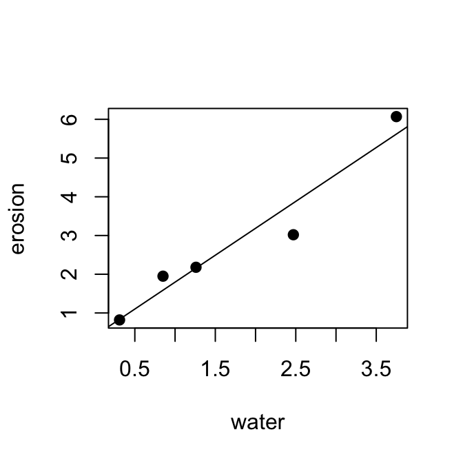

```r
plot(water,erosion,pch=19)
abline(fit)
```

Fitted regression line: $erosion = 0.406 + 1.390 * water$

### Fitted Values and Residuals

Fitted values: $\hat{y}_1 = \hat{\beta}_0 + \hat{\beta}_1x_i$

Residuals: $r_i = y_1 - \hat{y}_i$

The residuals are estimates of the unobserved $\epsilon_i's$.

### Sums of squares

$$TSS = \sum_{i=1}^n{(y_i-\bar{y})^2} \\
MSS = \sum_{i=1}^n{(\hat{y_i}-\bar{y})^2} \\
RSS = \sum_{i=1}^n{(y_i-\hat{y}_i)^2} \\
TSS \space (total) = MSS \space (model) + RSS \space (residual)$$

### Standard errors

#### SD and variance of beta hat:

$$se(\hat{\beta}_1) = \sqrt{\hat{Var}{\hat{\beta}}_1} \\
\hat{Var}(\hat{\beta}_1) = \frac{s_{x|y}^2}{(n-1)s_x^2}, where \\
s_x^2 = \sum_{i=1}^n\frac{(x_i-\hat{x})^2}{n-1}$$

### Hypothesis tests

#### Null

$H_0: \beta_1 = 0$

#### Test statistic

We reject the null for large values of |t|:

$$t = \frac{\hat{\beta}_1}{se(\hat{\beta}_1)}$$

T-distributed with n-2 df under null.

#### Confidence Intervals

95% CI for $\beta_1$:
$$\hat{\beta}_1 \pm c * se(\hat{\beta}_1),
\text {where c is the upper 97.5% (3.18) percentile in the t-distribution w/ n-2 df}$$

NB! The confidence interval does not contain 0 if and only if $p \leq 0.05$.

### Correlation and regression

The least squares estimate for the slope is given by:

$$\hat{\beta}_1 = r\frac{s_y}{s_x}, \\
\text{where sx and sy are the empirical standard deviations of the xis and yis}$$

NB! The test for $H_0: \beta_1 = 0$ in a linear regression model is numerically equivalent to the test for $H_0: rho = 0$ for bivariate data.

### Coefficient of determination, `R^2` “Multiple R-squared”

The proportion of the total variability in the outcomes (TSS) accounted for by the model (MSS).

$$R^2 = \frac{MSS}{TSS} = 1-\frac{RSS}{TSS} \\
R^2 = r^2 \text{ for the simple linear regression model}$$

# Lecture 3

## Topics

1. Multiple regression: data structure and basic questions
2. The multiple linear regression model
3. Categorical predictors
4. Planned experiments and observational studies

https://www.uio.no/studier/emner/matnat/math/STK4900/v21/lectures/lecture3.pdf

## Linear regression

### Model

- $y_i$ = outcome / response / dependent variable
- $x_i$ = predictor / covariate / (explanatory/independent) variable* \
- $\epsilon_i's$ = independent error terms (“noise”)
- $\beta_j$ is the change in $E(y|x)$ for an increase of one unit in the covariate $x_j$ holding all other covariates constant.

### Assumptions

1. $x_{ij}'s$ are considered to be fixed quantities
2. $\epsilon_i's$ are assumed to be $N(0,\sigma_\epsilon^2)$-distributed
3. fewer covariates than observations ($p \leq n \rightarrow$ unique least squares estimators

#### Multiple Linear Regression

$$\begin{align}
y_i &= E(y_1|x_i) + \epsilon_i \\
&= \beta_0 + \beta_1x_{1i} + \beta_2x_{2i} + ...+\beta_px_{pi} + \epsilon_i,
\end{align} \\
where \space x_i = (x_{1i}, x_{2i},...,x_{pi})$$

#### Simple Linear Regression

$$y_1 = E(y_1|x_i) + \epsilon_i = \beta_0 + \beta_1x_1+\epsilon_i$$

### Least squares

Ordinary Least Squares Regression, we minimize the MSE so that:

$$\hat{\beta} = argmin_{\beta}(y-X\beta)^2$$

#### Multiple Linear Regression

The estimates $\hat{\beta}_0, \hat{\beta}_1, ..., \hat{\beta}_p$ are obtained as values of $b_0, b_1,...,b_p$ that minimize the sum of squares:
$$\sum_{i=1}^n(y_i-E(y_1|x_i))^2 = \sum_{i=1}^n{(y_i-b_0-b_1x_{1i}-...-b_px_{pi})^2}$$

```r
# trees=read.table("http://www.uio.no/studier/emner/matnat/math/STK4900/data/trees.txt",header=T)
# fit.both=lm(volume~diameter+height, data=trees)
# summary(fit.both)
```

#### Simple Linear Regression

Estimated regression coefficients, $\hat{\beta}_0$ and $\hat{\beta}_1$, obtained as the values of $b_0$ and $b_1$ that minimize the sum of squares:
$$\sum_{i=1}^n(y_i-b_0-b_1x_i)^2$$

```r
water=c(0.31,0.85,1.26,2.47,3.75)
erosion=c(0.82,1.95,2.18,3.02,6.07)
fit=lm(erosion~water)
summary(fit)
```

```
##
## Call:
## lm(formula = erosion ~ water)
##
## Residuals:
##       1       2       3       4       5
## -0.0170  0.3624  0.0225 -0.8194  0.4514
##
## Coefficients:
##             Estimate Std. Error t value Pr(>|t|)
## (Intercept)    0.406      0.445    0.91    0.429
## water          1.390      0.210    6.63    0.007 **
## ---
## Signif. codes:  0 '***' 0.001 '**' 0.01 '*' 0.05 '.' 0.1 ' ' 1
##
## Residual standard error: 0.58 on 3 degrees of freedom
## Multiple R-squared:  0.936,  Adjusted R-squared:  0.915
## F-statistic:   44 on 1 and 3 DF,  p-value: 0.00699
```

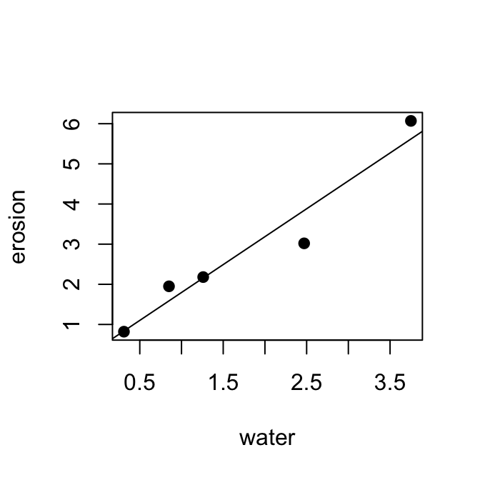

```r
plot(water,erosion,pch=19)
abline(fit)
```

Fitted regression line: $erosion = 0.406 + 1.390 * water$

The least squares estimate for the slope is given by:

$$\hat{\beta}_1 = r\frac{s_y}{s_x}, \\
\text{where sx and sy are the empirical standard deviations of the xis and yis}$$

### Transformations of the outcome / covariates

#### Multiple Linear Regression

Regression model linear in the parameters $\beta_j$, but allows for non-linear effects of the covariates, e.g.:

$$volume = \beta_0 + \beta_1diameter + \beta_2(diameter)^2 + \beta_3height + \epsilon$$

In R, add an I for Inhibit interpretation:

```r
# fit.both=lm(volume~diameter+I(diameter^2)+height, data=trees)
# summary(fit.both)
```

$$log(volume) = \beta_0 + \beta_1log(height) + \beta_2log(diameter) + \epsilon$$

```r
# fit.log=lm(log(volume)~log(height)+log(diameter), data=trees)
# summary(fit.log)
```

### Fitted values and residuals

#### Sums of squares

$$TSS = \sum_{i=1}^n{(y_i-\bar{y})^2} \\
MSS = \sum_{i=1}^n{(\hat{y_i}-\bar{y})^2} \\
RSS = \sum_{i=1}^n{(y_i-\hat{y}_i)^2} \\
TSS \space (total) = MSS \space (model) + RSS \space (residual)$$

#### Residuals

$r_i = y_i - \hat{y}_1$ The residuals are estimates of the unobserved $\epsilon_i's$.

#### Fitted values

##### Multiple linear regression

$\hat{y}_i = \hat{\beta}_0 + \hat{\beta_1x_{1i}} + ... + \hat{\beta_px_{pi}}$

##### Simple linear regression

$\hat{y}_1 = \hat{\beta}_0 + \hat{\beta}_1x_i$

### Coefficient of determination, `R^2` “Multiple R-squared”

The proportion of the total variability in the outcomes (TSS) accounted for by the model (MSS).

$$R^2 = \frac{MSS}{TSS} = 1-\frac{RSS}{TSS}$$

#### Multiple Linear Regression

The multiple correlation coefficient,
$$r = \sqrt{R^2},$$
is the Pearson correlation coefficient btw the outcomes $(y_i)$ and the fitted values $(\hat{y}_i)$.

#### Simple Linear Regression

$$R^2 = r^2 \text{ for the simple linear regression model}$$